# Extracting and visualizing tidy draws from rstanarm models

## Posterior means and predictions

Rather than calculating conditional means manually as in the previous example, we could use `add_epred_draws()`, which is analogous to `rstanarm::posterior_epred()` (giving posterior draws from the expectation of the posterior predictive; i.e. posterior distributions of conditional means), but uses a tidy data format. We can combine it with `modelr::data_grid()` to first generate a grid describing the predictions we want, then transform that grid into a long-format data frame of draws from conditional means:

```r
ABC %>%
  data_grid(condition) %>%
  add_epred_draws(m) %>%
  head(10)
```

| condition | .row | .chain | .iteration | .draw | .epred |
| --- | --- | --- | --- | --- | --- |
| A | 1 | NA | NA | 1 | 0.2029359 |
| A | 1 | NA | NA | 2 | 0.0815057 |
| A | 1 | NA | NA | 3 | 0.3493703 |
| A | 1 | NA | NA | 4 | 0.1644948 |
| A | 1 | NA | NA | 5 | 0.1214448 |
| A | 1 | NA | NA | 6 | 0.6316470 |
| A | 1 | NA | NA | 7 | 0.0172222 |
| A | 1 | NA | NA | 8 | 0.1675855 |
| A | 1 | NA | NA | 9 | 0.5015429 |
| A | 1 | NA | NA | 10 | 0.0394944 |

To plot this example, we’ll also show the use of `ggdist::stat_pointinterval()` instead of `ggdist::geom_pointinterval()`, which summarizes draws into point summaries and intervals within ggplot:

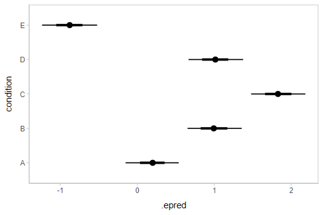

```r
ABC %>%
  data_grid(condition) %>%
  add_epred_draws(m) %>%
  ggplot(aes(x = .epred, y = condition)) +
  stat_pointinterval(.width = c(.66, .95))
```

## Quantile dotplots

Intervals are nice if the alpha level happens to line up with whatever decision you are trying to make, but getting a shape of the posterior is better (hence eye plots, above). On the other hand, making inferences from density plots is imprecise (estimating the area of one shape as a proportion of another is a hard perceptual task). Reasoning about probability in frequency formats is easier, motivating [quantile dotplots](https://github.com/mjskay/when-ish-is-my-bus/blob/master/quantile-dotplots.md) ([Kay et al. 2016](https://doi.org/10.1145/2858036.2858558), [Fernandes et al. 2018](https://doi.org/10.1145/3173574.3173718)), which also allow precise estimation of arbitrary intervals (down to the dot resolution of the plot, 100 in the example below).

Within the slabinterval family of geoms in tidybayes is the `dots` and `dotsinterval` family, which automatically determine appropriate bin sizes for dotplots and can calculate quantiles from samples to construct quantile dotplots. `ggdist::stat_dotsinterval()` is the horizontal variant designed for use on samples:

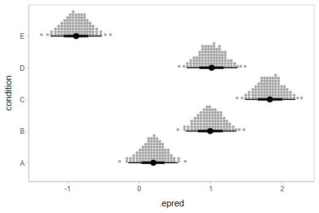

```r
ABC %>%
  data_grid(condition) %>%
  add_epred_draws(m) %>%
  ggplot(aes(x = .epred, y = condition)) +
  stat_dotsinterval(quantiles = 100)
```

The idea is to get away from thinking about the posterior as indicating one canonical point or interval, but instead to represent it as (say) 100 approximately equally likely points.

## Posterior predictions

Where `add_epred_draws()` is analogous to `rstanarm::posterior_epred()`, `add_predicted_draws()` is analogous to `rstanarm::posterior_predict()`, giving draws from the posterior predictive distribution.

We could use `tidybayes::stat_interval()` to plot predictive bands alongside the data and posterior distributions of the means:

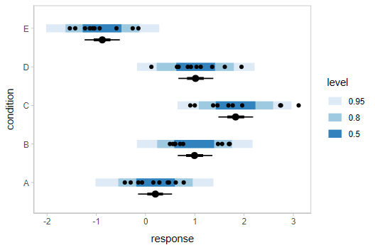

```r
grid = ABC %>%
  data_grid(condition)

means = grid %>%
  add_epred_draws(m)

preds = grid %>%
  add_predicted_draws(m)

ABC %>%
  ggplot(aes(y = condition, x = response)) +
  stat_interval(aes(x = .prediction), data = preds) +
  stat_pointinterval(aes(x = .epred), data = means, .width = c(.66, .95), position = position_nudge(y = -0.3)) +
  geom_point() +
  scale_color_brewer()
```

## Fit/prediction curves

To demonstrate drawing fit curves with uncertainty, let’s fit a slightly naive model to part of the `mtcars` dataset:

```r
m_mpg = stan_glm(mpg ~ hp * cyl, data = mtcars)
```

We can plot fit curves with probability bands:

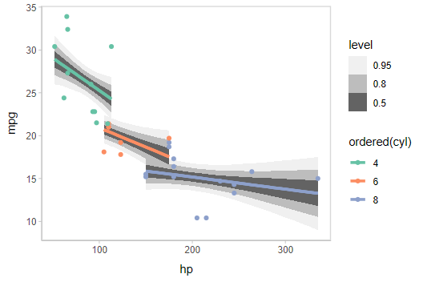

```r
mtcars %>%
  group_by(cyl) %>%
  data_grid(hp = seq_range(hp, n = 51)) %>%
  add_epred_draws(m_mpg) %>%
  ggplot(aes(x = hp, y = mpg, color = ordered(cyl))) +
  stat_lineribbon(aes(y = .epred)) +
  geom_point(data = mtcars) +
  scale_fill_brewer(palette = "Greys") +
  scale_color_brewer(palette = "Set2")
```

Or we can sample a reasonable number of fit lines (say 100) and overplot them:

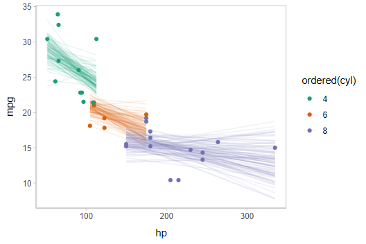

```r
mtcars %>%
  group_by(cyl) %>%
  data_grid(hp = seq_range(hp, n = 101)) %>%
  # NOTE: this shows the use of ndraws to subsample within add_epred_draws()
  # ONLY do this IF you are planning to make spaghetti plots, etc.
  # NEVER subsample to a small sample to plot intervals, densities, etc.
  add_epred_draws(m_mpg, ndraws = 100) %>%
  ggplot(aes(x = hp, y = mpg, color = ordered(cyl))) +
  geom_line(aes(y = .epred, group = paste(cyl, .draw)), alpha = .1) +
  geom_point(data = mtcars) +
  scale_color_brewer(palette = "Dark2")
```

Or we could plot posterior predictions (instead of means). For this example we’ll also use `alpha` to make it easier to see overlapping bands:

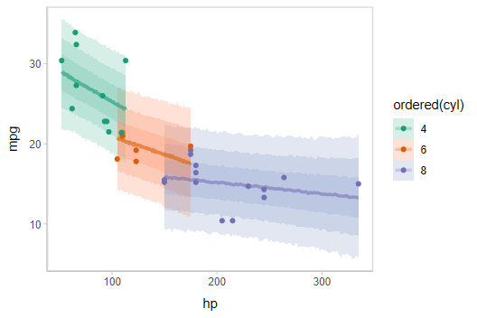

```r
mtcars %>%
  group_by(cyl) %>%
  data_grid(hp = seq_range(hp, n = 101)) %>%
  add_predicted_draws(m_mpg) %>%
  ggplot(aes(x = hp, y = mpg, color = ordered(cyl), fill = ordered(cyl))) +
  stat_lineribbon(aes(y = .prediction), .width = c(.95, .80, .50), alpha = 1/4) +
  geom_point(data = mtcars) +
  scale_fill_brewer(palette = "Set2") +
  scale_color_brewer(palette = "Dark2")
```

See `vignette("tidy-brms")` for additional examples of fit lines, including animated [hypothetical outcome plots (HOPs)](https://mucollective.northwestern.edu/project/hops-trends).

## Comparing levels of a factor

If we wish compare the means from each condition, `compare_levels()` facilitates comparisons of the value of some variable across levels of a factor. By default it computes all pairwise differences.

Let’s demonstrate `compare_levels()` with `ggdist::stat_halfeye()`. We’ll also re-order by the mean of the difference:

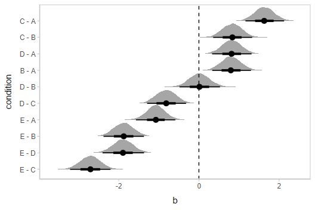

```r
m %>%
  spread_draws(b[,,condition], sep = "[, :]") %>%
  compare_levels(b, by = condition) %>%
  ungroup() %>%
  mutate(condition = reorder(condition, b)) %>%
  ggplot(aes(y = condition, x = b)) +
  stat_halfeye() +
  geom_vline(xintercept = 0, linetype = "dashed")
```

## Ordinal models

### Ordinal model with categorical predictor

Here’s an ordinal model with a categorical predictor:

```r
data(esoph)
m_esoph_rs = stan_polr(tobgp ~ agegp, data = esoph, prior = R2(0.25), prior_counts = rstanarm::dirichlet(1))
```

The `rstanarm::posterior_linpred()` function for ordinal regression models in rstanarm returns the link-level prediction for each draw (in contrast to `brms::posterior_epred()`, which returns one prediction per category for ordinal models, see the ordinal regression examples in `vignette("tidy-brms")`). Unfortunately, `rstanarm::posterior_epred()` does not provide this format. The philosophy of `tidybayes` is to tidy whatever format is output by a model, so in keeping with that philosophy, when applied to ordinal `rstanarm` models, we will use examples with `add_linpred_draws()` and show how to transform them into predicted per-category probabilities.

For example, here is a plot of the link-level fit:

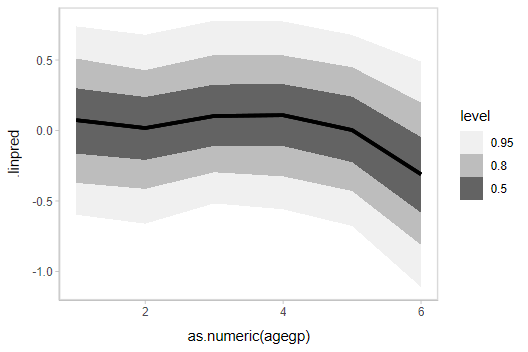

```r
esoph %>%
  data_grid(agegp) %>%
  add_linpred_draws(m_esoph_rs) %>%
  ggplot(aes(x = as.numeric(agegp), y = .linpred)) +
  stat_lineribbon() +
  scale_fill_brewer(palette = "Greys")
```

This can be hard to interpret. To turn this into predicted probabilities on a per-category basis, we have to use the fact that an ordinal logistic regression defines the probability of an outcome in category $j$ **or less** as:

$$\textrm{logit}\left[Pr(Y\le j)\right] = \alpha_j - \beta x$$

Thus, the probability of category $j$ is:

$$\begin{align}
Pr(Y = j) &= Pr(Y \le j) - Pr(Y \le j - 1)\\
&= \textrm{logit}^{-1}(\alpha_j - \beta x) -
\textrm{logit}^{-1}(\alpha_{j-1} - \beta x)
\end{align}$$

To derive these values, we need two things:

- The $\alpha_j$ values. These are threshold parameters fitted by the model. For convenience, if there are $k$ levels, we will take $\alpha_k = +\infty$, since the probability of being in the top level or below it is 1.
- The $\beta x$ values. These are just the `.linpred` values returned by `add_linpred_draws()`.

The thresholds in `rstanarm` are coefficients with names containing `|`, indicating which categories they are thresholds between. We can see those parameters in the list of variables in the model:

```r
get_variables(m_esoph_rs)
```

```
##  [1] "agegp.L"        "agegp.Q"        "agegp.C"        "agegp^4"        "agegp^5"        "0-9g/day|10-19"
##  [7] "10-19|20-29"    "20-29|30+"      "accept_stat__"  "stepsize__"     "treedepth__"    "n_leapfrog__"
## [13] "divergent__"    "energy__"
```

We can extract those automatically by using the `regex = TRUE` argument to `gather_draws()` to find all variables containing a `|` character. We will then use `dplyr::summarise_all(list)` to turn these thresholds into a list column, and add a final threshold equal to $+\infty$ (to represent the highest category):

```r
thresholds = m_esoph_rs %>%
  gather_draws(`.*[|].*`, regex = TRUE) %>%
  group_by(.draw) %>%
  select(.draw, threshold = .value) %>%
  summarise_all(list) %>%
  mutate(threshold = map(threshold, ~ c(., Inf)))

head(thresholds, 10)
```

| .draw | threshold |
| --- | --- |
| 1 | -0.9705395, 0.1546626, 1.0081490, Inf |
| 2 | -0.9440384, 0.4085346, 1.3570899, Inf |
| 3 | -0.9003523, 0.3782366, 1.2743608, Inf |
| 4 | -1.2188781, 0.0994917, 1.3055824, Inf |
| 5 | -0.9174891, 0.2009267, 1.2257299, Inf |
| 6 | -1.09787791, 0.08797248, 1.18605543, Inf |
| 7 | -0.87089841, 0.09926307, 1.47029966, Inf |
| 8 | -1.0844373, 0.4159425, 1.2738333, Inf |
| 9 | -0.5233614, 0.4653772, 1.6083016, Inf |
| 10 | -1.2770482, 0.2212309, 1.0815977, Inf |

For example, the threshold vector from one row of this data frame (i.e., from one draw from the posterior) looks like this:

```r
thresholds[1,]$threshold
```

```
## [[1]]
## [1] -0.9705395  0.1546626  1.0081490        Inf
```

We can combine those thresholds (the $\alpha_j$ values from the above formula) with the `.linpred` column from `add_linpred_draws()` ($\beta x$ from the above formula) to calculate per-category probabilities:

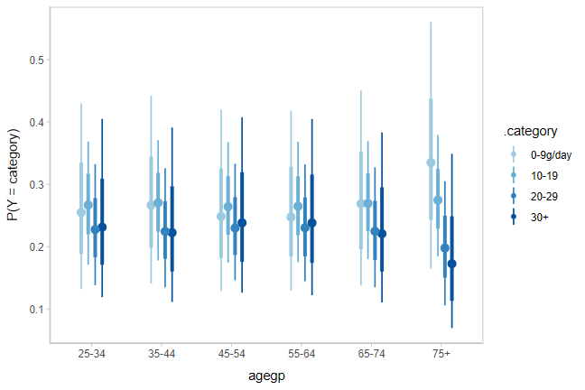

```r
esoph %>%
  data_grid(agegp) %>%
  add_linpred_draws(m_esoph_rs) %>%
  inner_join(thresholds, by = ".draw", multiple = "all") %>%
  mutate(`P(Y = category)` = map2(threshold, .linpred, function(alpha, beta_x)
      # this part is logit^-1(alpha_j - beta*x) - logit^-1(alpha_j-1 - beta*x)
      plogis(alpha - beta_x) -
      plogis(lag(alpha, default = -Inf) - beta_x)
    )) %>%
  mutate(.category = list(levels(esoph$tobgp))) %>%
  unnest(c(threshold, `P(Y = category)`, .category)) %>%
  ggplot(aes(x = agegp, y = `P(Y = category)`, color = .category)) +
  stat_pointinterval(position = position_dodge(width = .4)) +
  scale_size_continuous(guide = "none") +
  scale_color_manual(values = brewer.pal(6, "Blues")[-c(1,2)])
```

It is hard to see the changes in categories in the above plot; let’s try something that gives a better gist of the distribution within each year:

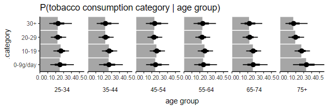

```r
esoph_plot = esoph %>%
  data_grid(agegp) %>%
  add_linpred_draws(m_esoph_rs) %>%
  inner_join(thresholds, by = ".draw", multiple = "all") %>%
  mutate(`P(Y = category)` = map2(threshold, .linpred, function(alpha, beta_x)
      # this part is logit^-1(alpha_j - beta*x) - logit^-1(alpha_j-1 - beta*x)
      plogis(alpha - beta_x) -
      plogis(lag(alpha, default = -Inf) - beta_x)
    )) %>%
  mutate(.category = list(levels(esoph$tobgp))) %>%
  unnest(c(threshold, `P(Y = category)`, .category)) %>%
  ggplot(aes(x = `P(Y = category)`, y = .category)) +
  coord_cartesian(expand = FALSE) +
  facet_grid(. ~ agegp, switch = "x") +
  theme_classic() +
  theme(strip.background = element_blank(), strip.placement = "outside") +
  ggtitle("P(tobacco consumption category | age group)") +
  xlab("age group")

esoph_plot +
  stat_summary(fun = median, geom = "bar", fill = "gray65", width = 1, color = "white") +
  stat_pointinterval()
```

The bars in this case might present a false sense of precision, so we could also try CCDF barplots instead:

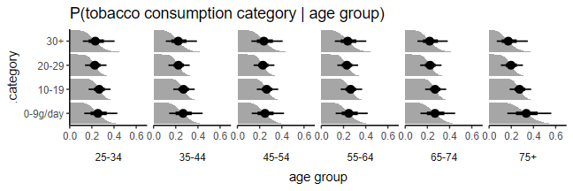

```r
esoph_plot +
  stat_ccdfinterval() +
  expand_limits(x = 0) #ensure bars go to 0
```

This output should be very similar to the output from the corresponding `m_esoph_brm` model in `vignette("tidy-brms")` (modulo different priors), though it takes a bit more work to produce in `rstanarm` compared to `brms`.